# Atividade Integradora

Membros * Bruno * Henrique * Yuri

## Set Up chuncks

```r
knitr::opts_chunk$set(warning = FALSE)
```

```r
library(reticulate)
```

## Importação das principais bibliotecas que serão utilizadas

```python
import pandas as pd
import numpy as np
```

## Criação do dataframe utilizando o pandas como bilbioteca de manipulação de bases

```python
df1 = pd.read_feather("BD_PRE.feather")
```

## Describe

```python
df1.describe()
```

```
##               IDTNS       ANO_BASE  ...           PESO            I2
## count  1.284110e+05  128411.000000  ...  128411.000000  84441.000000
## mean   2.062114e+07    2016.269774  ...       0.999992      1.179806
## std    2.192746e+07       1.120365  ...       1.315625      0.384028
## min    3.780000e+02    2015.000000  ...       0.015936      1.000000
## 25%    6.160118e+06    2015.000000  ...       0.180556      1.000000
## 50%    6.804225e+06    2016.000000  ...       0.601990      1.000000
## 75%    4.105798e+07    2017.000000  ...       1.348837      1.000000
## max    6.203986e+07    2018.000000  ...      10.965368      2.000000
##
## [8 rows x 47 columns]
```

### As variáveis foram retiradas por possuírem valores categóricos e únicos que não seriam interessantes para análise. Pois, sem variância destas features não agregariam em nada para o modelo.

```python
df1=df1.drop(["IDTNS","TIPO","DATA","H0","Q1","Q2","Q3","Q4","Q6","Q7"],axis=1)

df1.head()
```

```
##   OPERADORA ESTADO  ANO_BASE  Q5  Q8  ...      H2  H2a  I1      PESO   I2
## 0        OI     RJ      2018   1  44  ...  999998    1   2  1.165414  2.0
## 1        OI     BA      2018   1  50  ...  999998    6   1  1.911877  1.0
## 2      VIVO     ES      2018   1  37  ...    1000    1   1  0.695489  1.0
## 3     CLARO     RR      2018   1  19  ...  999998    2   1  0.054054  1.0
## 4        OI     ES      2018   1  39  ...  999998    7   1  0.111111  1.0
##
## [5 rows x 42 columns]
```

## Renomeação da coluna J1 para target facilitando a análise da base

```python
df1 = df1.rename(columns = {'J1':'Target'})
```

```python
df1.head()
```

```
##   OPERADORA ESTADO  ANO_BASE  Q5  Q8  ...      H2  H2a  I1      PESO   I2
## 0        OI     RJ      2018   1  44  ...  999998    1   2  1.165414  2.0
## 1        OI     BA      2018   1  50  ...  999998    6   1  1.911877  1.0
## 2      VIVO     ES      2018   1  37  ...    1000    1   1  0.695489  1.0
## 3     CLARO     RR      2018   1  19  ...  999998    2   1  0.054054  1.0
## 4        OI     ES      2018   1  39  ...  999998    7   1  0.111111  1.0
##
## [5 rows x 42 columns]
```

## Realizando a limpeza da base de acordo com o metadados disponibilizada no site do governo. Para cada variável foi feita uma manipulação de dados, no caso abaixo para toda variável em que o valor era 99 foi definida que esta seria missing.

```python
df2 =  df1.copy()
```

```python
df2['B1_1'].replace([99], np.NaN,inplace = True)
df2['B1_2'].replace([99], np.NaN,inplace = True)
df2['C1_1'].replace([99], np.NaN,inplace = True)
df2['C1_2'].replace([99], np.NaN,inplace = True)
df2['D2_1'].replace([99], np.NaN,inplace = True)
df2['D2_2'].replace([99], np.NaN,inplace = True)
df2['D2_3'].replace([99], np.NaN,inplace = True)
df2['F5'].replace([99], np.NaN,inplace = True)
df2['F4'].replace([99], np.NaN,inplace = True)
df2['F2'].replace([99], np.NaN,inplace = True)
df2['A5'].replace([99], np.NaN,inplace = True)
df2['A4'].replace([99], np.NaN,inplace = True)
df2['A3'].replace([99], np.NaN,inplace = True)
df2['A2_1'].replace([99], np.NaN,inplace = True)
df2['A2_2'].replace([99], np.NaN,inplace = True)
df2['A2_3'].replace([99], np.NaN,inplace = True)
df2['E1_1'].replace([99], np.NaN,inplace = True)
df2['E1_2'].replace([99], np.NaN,inplace = True)
df2['E1_3'].replace([99], np.NaN,inplace = True)
df2['F4'].replace([99], np.NaN,inplace = True)
df2['F5'].replace([99], np.NaN,inplace = True)
df2['F6'].replace([99], np.NaN,inplace = True)
```

## Mesmo caso anterior, porém para os outros casos de valores considerados como missing.

```python
df2['Q8'].replace([999999], np.NaN,inplace = True)
df2['H1'].replace([99,99999], np.NaN,inplace = True)
df2['H2'].replace([99997,99998,99999,100000,999998,999999], np.NaN,inplace = True)
```

## A feature H2a foi removida, pois logo após seria criada um novo range de valores de salários nomeada como RIQUEZA

```python
df2.drop(["H2a"],inplace = True,axis = 1)
```

```python
df3 = df2.copy()
```

```python
df3.loc[(df3["H2"] >=0) & (df3["H2"] <1000), "RIQUEZA"]=1
df3.loc[(df3["H2"] >=1000) & (df3["H2"] <3000), "RIQUEZA"]=2
df3.loc[(df3["H2"] >=3000) & (df3["H2"] <6000), "RIQUEZA"]=3
df3.loc[(df3["H2"] >=6000) & (df3["H2"] <10000), "RIQUEZA"]=4
df3.loc[(df3["H2"] >=10000) & (df3["H2"] <15000), "RIQUEZA"]=5
df3.loc[(df3["H2"] >=15000) & (df3["H2"] <20000), "RIQUEZA"]=6
df3.loc[(df3["H2"] >=20000), "RIQUEZA"]=7
```

```python
df3.RIQUEZA.value_counts(dropna =False)
```

```
## 2.0    48387
## 1.0    33554
## NaN    29784
## 3.0    12543
## 4.0     2704
## 5.0      850
## 7.0      315
## 6.0      274
## Name: RIQUEZA, dtype: int64
```

## Target Variable

```
    No código abaixo, foi definida para os valores de 99 para a Target e logo após todas as linhas que continha Target iguais a missing foram removidas da análise. Além disso, foi criada uma nova variável Target2 definindo se a nota da operadora foi RUIM (0) ou se a nota foi BOA (1).
```

```python
df3['Target'].replace([99], np.NaN,inplace = True)

df3.loc[(df3["Target"] <=8) ,"Target2"]= 0
df3.loc[(df3["Target"] >8 ) ,"Target2"]= 1


df3.dropna(subset=['Target'],inplace = True)
```

```python
df3.describe()
```

```
##             ANO_BASE             Q5  ...       RIQUEZA        Target2
## count  128198.000000  128198.000000  ...  98524.000000  128198.000000
## mean     2016.269450       1.029447  ...      1.895223       0.287391
## std         1.120052       0.169055  ...      0.876366       0.452547
## min      2015.000000       1.000000  ...      1.000000       0.000000
## 25%      2015.000000       1.000000  ...      1.000000       0.000000
## 50%      2016.000000       1.000000  ...      2.000000       0.000000
## 75%      2017.000000       1.000000  ...      2.000000       1.000000
## max      2018.000000       2.000000  ...      7.000000       1.000000
##
## [8 rows x 41 columns]
```

Variaveis Categoricas Moda Estado  
Operadora  
RIQUEZA  
Q9  
I1 D1  
Q5  
F1 F3  
F5  
G1

Variaveis Categoricas Missing Explicito A1_x

## No código abaixo identificamos que existiam features em que caso o valor estivesse como missing ele representava igual a 0.

```python
df3["A1_1"].fillna(0,inplace = True)
df3["A1_2"].fillna(0,inplace = True)
df3["A1_3"].fillna(0,inplace = True)
df3["A1_4"].fillna(0,inplace = True)
df3["F1"].fillna(0,inplace = True)
df3["F3"].fillna(0,inplace = True)
df3["F5"].fillna(0,inplace = True)
```

## Após a correção de todos os valores da base, o código abaixo definiu no dataframe se todas as variáveis que seriam categóricas.

```python
df3['Q9'] = df3['Q9'].astype('category')
df3['I1'] = df3['I1'].astype('category')
df3['D1'] = df3['D1'].astype('category')
df3['Q5'] = df3['Q5'].astype('category')
df3['F1'] = df3['F1'].astype('category')
df3['F3'] = df3['F3'].astype('category')
df3['F5'] = df3['F5'].astype('category')
df3['G1'] = df3['G1'].astype('category')
df3["A1_1"] =  df3['A1_1'].astype('category')
df3["A1_2"] =  df3['A1_2'].astype('category')
df3["A1_3"] =  df3['A1_3'].astype('category')
df3["A1_4"] =  df3['A1_4'].astype('category')
df3["RIQUEZA"] =  df3['RIQUEZA'].astype('category')
df3["Target2"] =  df3['Target2'].astype('category')
```

```python
df3.dtypes
```

```
## OPERADORA      object
## ESTADO         object
## ANO_BASE        int64
## Q5           category
## Q8            float64
## Q8a             int64
## Q9           category
## Target        float64
## B1_1          float64
## B1_2          float64
## C1_1          float64
## C1_2          float64
## D1           category
## D2_1          float64
## D2_2          float64
## D2_3          float64
## E1_1          float64
## E1_2          float64
## E1_3          float64
## A1_1         category
## A1_2         category
## A1_3         category
## A1_4         category
## A2_1          float64
## A2_2          float64
## A2_3          float64
## A3            float64
## A4            float64
## A5            float64
## F1           category
## F2            float64
## F3           category
## F4            float64
## F5           category
## F6            float64
## G1           category
## H1            float64
## H2            float64
## I1           category
## PESO          float64
## I2            float64
## RIQUEZA      category
## Target2      category
## dtype: object
```

## Realizar a importação dos modelos que serão utilizados

```python
from sklearn.linear_model import LogisticRegression
from sklearn.model_selection import train_test_split
from sklearn.tree import DecisionTreeClassifier
from sklearn.ensemble import RandomForestClassifier
from sklearn.neighbors import KNeighborsClassifier
```

## Separação da base de dados em features e Target

Para as variáveis que dependiam da resposta de outras, estas foram retiradas da análise. Desta forma, foram apenas contempladas as variáveis que seja indepedentes de outras.

```python
df4=df3.loc[:,['Q5','Q8','Q8a','Q9','B1_1','B1_2','C1_1','C1_2','D1','D2_1','D2_2','D2_3','E1_1','E1_2','E1_3','A1_1','A1_2','A1_3','A1_4','F1','F3','F5','G1','H1','I1','PESO','RIQUEZA',"Target2"]]
```

```r
df <- py$df4
```

# Inicio R

```r
library(DataExplorer)
library(tidyverse)
library(tidymodels)
library(furrr)
library(h2o)
library(DALEX)
library(iBreakDown)
library(ingredients)
DataExplorer::introduce(df)
```

```
##     rows columns discrete_columns continuous_columns all_missing_columns
## 1 128198      28               14                 14                   0
##   total_missing_values complete_rows total_observations memory_usage
## 1               218989         51924            3589544     21551024
```

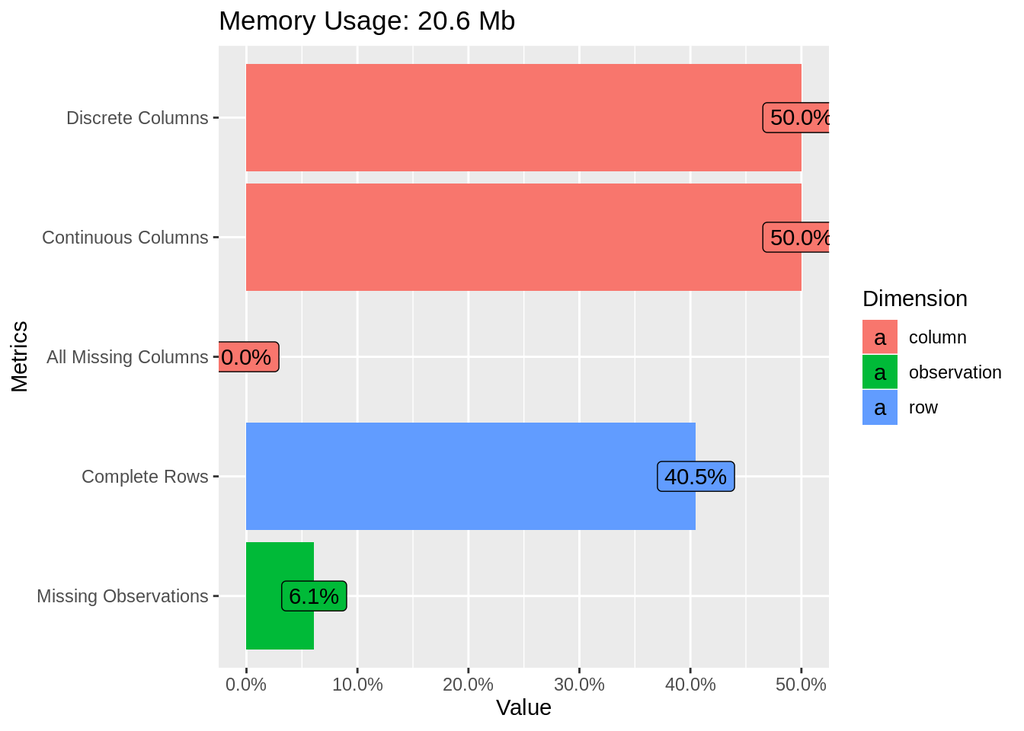

```r
DataExplorer::plot_intro(df)
```

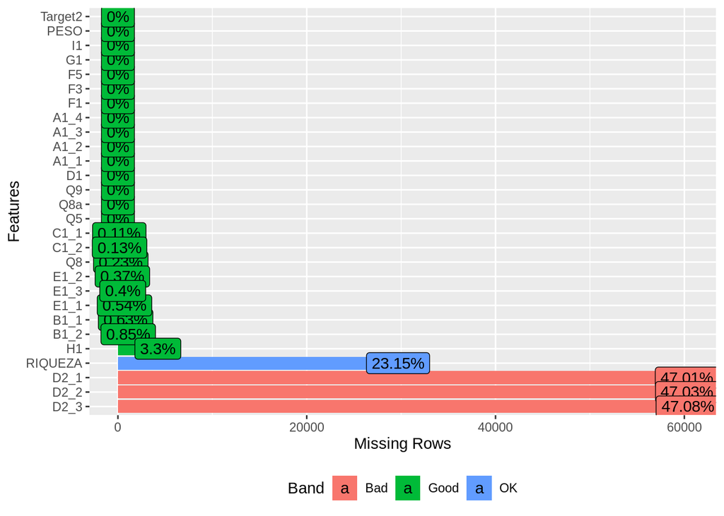

```r
plot_missing(df)
```

```r
df <- df %>%
  select(-starts_with("D2"))
```

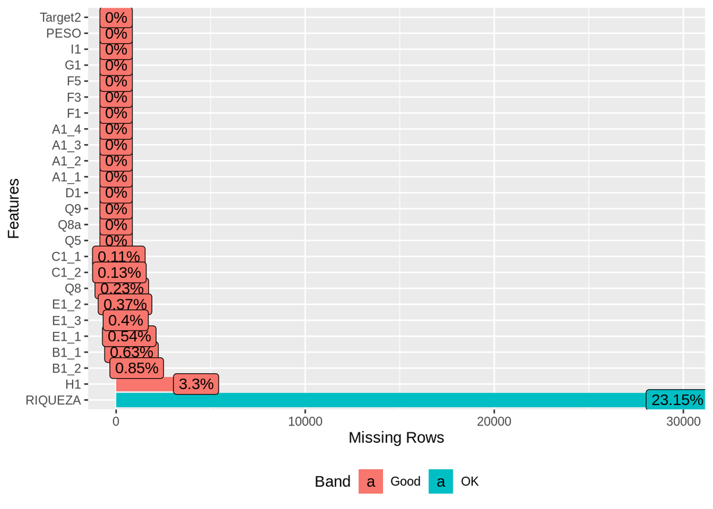

```r
plot_missing(df)
```

```r
#df <- df %>%
#  mutate(RIQUEZA = RIQUEZA %>% fct_explicit_na())
```

```r
  df <- df %>%
  rename(response = Target2) %>%
  select(-PESO)
```

```r
  df2 <- df %>%
  mutate(response = response %>% fct_recode(bad = "0",good ="1"))
```

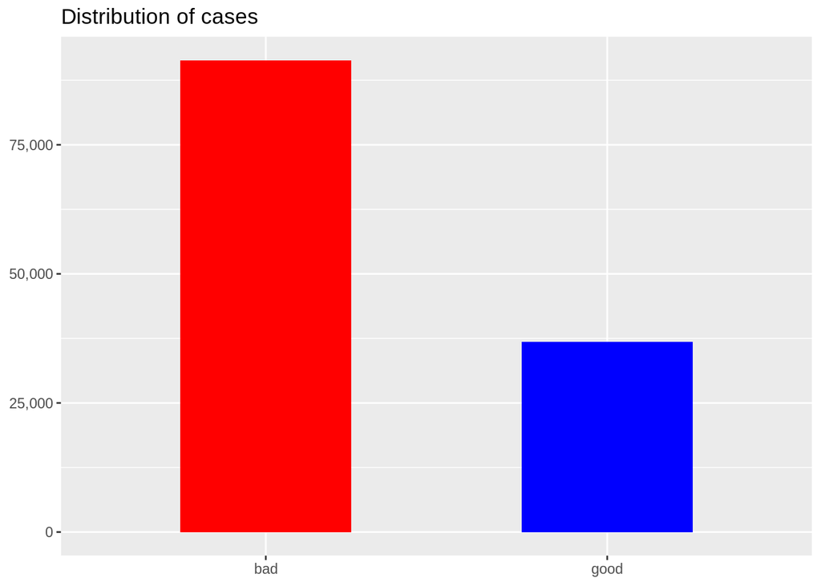

```r
df2 %>%
  count(response) %>%
  ggplot(aes(response, n, fill = response)) +
  geom_col(width = .5, show.legend = FALSE) +
  scale_y_continuous(labels = scales::comma) +
  scale_fill_manual(values = c("red","blue")) +
  labs(
    x = NULL,
    y = NULL,
    title = "Distribution of cases"
  )
```

# Modelagem

```r
telefone_initial_split <- df %>% rsample::initial_split(prop = 0.9)
telefone_initial_split
```

```
## <115379/12819/128198>
```

```r
train_data <- training(telefone_initial_split)
test_data <- testing(telefone_initial_split)
```

```r
recipe_telefone <-
  recipe(response ~.,data = train_data) %>%
  #step_upsample(response,skip = TRUE) %>%
  step_normalize(all_numeric()) %>%
  step_modeimpute(all_predictors(),-all_numeric()) %>%
  step_medianimpute(all_predictors(),-all_nominal()) #%>%
  #step_dummy(all_predictors(),-all_numeric())
```

```r
recipe_telefone %>% prep(retain = TRUE)
```

```
## Data Recipe
##
## Inputs:
##
##       role #variables
##    outcome          1
##  predictor         23
##
## Training data contained 115379 data points and 28962 incomplete rows.
##
## Operations:
##
## Centering and scaling for Q8, Q8a, B1_1, B1_2, C1_1, C1_2, ... [trained]
## Mode Imputation for Q5, Q9, D1, A1_1, A1_2, A1_3, A1_4, F1, ... [trained]
## Median Imputation for Q8, Q8a, B1_1, B1_2, C1_1, C1_2, ... [trained]
```

## Logistic

```r
simple_model_recipe <- recipe_telefone %>%
  prep(retain = TRUE)

simple_train <- simple_model_recipe %>% juice()

simple_test <- simple_model_recipe %>% bake(test_data)

logistic_regression <-
  logistic_reg(mode = "classification",penalty = 0) %>%
  set_engine("glmnet") %>%
  fit(response ~.,data = simple_train)

logistic_regression %>%
  predict(simple_test) %>%
  bind_cols(simple_test %>% select(response)) %>%
  metrics(truth = response,estimate = .pred_class)
```

```
## # A tibble: 2 x 3
##   .metric  .estimator .estimate
##   <chr>    <chr>          <dbl>
## 1 accuracy binary         0.827
## 2 kap      binary         0.562
```

```r
logistic_regression %>%
  predict(simple_test,type = "prob") %>%
  bind_cols(simple_test %>% select(response)) %>%
  roc_auc(truth = response,predictor =.pred_0)
```

```
## # A tibble: 1 x 3
##   .metric .estimator .estimate
##   <chr>   <chr>          <dbl>
## 1 roc_auc binary         0.874
```

```r
lasso_regression <- logistic_reg(mode = "classification",mixture = 0) %>%
  set_engine("glmnet") %>%
  fit(response~ .,data = simple_train)

lasso_regression %>%
  multi_predict(new_data = simple_test,type = "prob") %>%
  bind_cols(simple_test) %>%
  unnest() %>%
  group_by(penalty) %>%
  do(ok = roc_auc(.,truth = response,predictor = .pred_0)) %>%
  unnest() %>%
  spread(key = .metric,value = .estimate) %>%
  arrange(roc_auc %>% desc)
```

```
## # A tibble: 100 x 3
##    penalty .estimator roc_auc
##      <dbl> <chr>        <dbl>
##  1  0.0202 binary       0.873
##  2  0.0222 binary       0.873
##  3  0.0244 binary       0.872
##  4  0.0267 binary       0.872
##  5  0.0293 binary       0.872
##  6  0.0322 binary       0.872
##  7  0.0353 binary       0.872
##  8  0.0388 binary       0.872
##  9  0.0426 binary       0.872
## 10  0.0467 binary       0.871
## # … with 90 more rows
```

```r
ridge_regression <- logistic_reg(mode = "classification",mixture = 1) %>%
  set_engine("glmnet") %>%
  fit(response~ .,data = simple_train)

ridge_regression %>%
  multi_predict(new_data = simple_test,type = "prob") %>%
  bind_cols(simple_test) %>%
  unnest() %>%
  group_by(penalty) %>%
  do(ok = roc_auc(.,truth = response,predictor = .pred_0)) %>%
  unnest() %>%
  spread(key = .metric,value = .estimate) %>%
  arrange(roc_auc %>% desc)
```

```
## # A tibble: 68 x 3
##     penalty .estimator roc_auc
##       <dbl> <chr>        <dbl>
##  1 0.00110  binary       0.874
##  2 0.00121  binary       0.874
##  3 0.00133  binary       0.874
##  4 0.00101  binary       0.874
##  5 0.00146  binary       0.874
##  6 0.00176  binary       0.874
##  7 0.000917 binary       0.874
##  8 0.000836 binary       0.874
##  9 0.00160  binary       0.874
## 10 0.000762 binary       0.874
## # … with 58 more rows
```

## Random Forest

```r
  random_forest <- rand_forest(mode = "classification",trees = 100) %>%
  set_engine("ranger") %>%
  fit(response~ .,data = simple_train)

random_forest %>%
    predict(simple_test) %>%
    bind_cols(simple_test %>% select(response)) %>%
    metrics(truth = response,estimate = .pred_class)
```

```
## # A tibble: 2 x 3
##   .metric  .estimator .estimate
##   <chr>    <chr>          <dbl>
## 1 accuracy binary         0.828
## 2 kap      binary         0.561
```

```r
random_forest %>%
  predict(simple_test,type = "prob") %>%
  bind_cols(simple_test %>% select(response)) %>%
  roc_auc(truth = response,predictor =.pred_0)
```

```
## # A tibble: 1 x 3
##   .metric .estimator .estimate
##   <chr>   <chr>          <dbl>
## 1 roc_auc binary         0.887
```

## h2o

### Start CLuster

```r
library(h2o)
library(DALEXtra)
h2o.init(nthreads = 12,max_mem_size = "8g")
```

```
##
## H2O is not running yet, starting it now...
##
## Note:  In case of errors look at the following log files:
##     /tmp/RtmpLscoSh/h2o_bruno_started_from_r.out
##     /tmp/RtmpLscoSh/h2o_bruno_started_from_r.err
##
##
## Starting H2O JVM and connecting: . Connection successful!
##
## R is connected to the H2O cluster:
##     H2O cluster uptime:         1 seconds 322 milliseconds
##     H2O cluster timezone:       America/Sao_Paulo
##     H2O data parsing timezone:  UTC
##     H2O cluster version:        3.26.0.2
##     H2O cluster version age:    1 month and 4 days
##     H2O cluster name:           H2O_started_from_R_bruno_ggm486
##     H2O cluster total nodes:    1
##     H2O cluster total memory:   8.00 GB
##     H2O cluster total cores:    16
##     H2O cluster allowed cores:  12
##     H2O cluster healthy:        TRUE
##     H2O Connection ip:          localhost
##     H2O Connection port:        54321
##     H2O Connection proxy:       NA
##     H2O Internal Security:      FALSE
##     H2O API Extensions:         Amazon S3, XGBoost, Algos, AutoML, Core V3, Core V4
##     R Version:                  R version 3.6.1 (2019-07-05)
```

### Upload df’s

```r
simple_train_hex <-  as.h2o(simple_train)
simple_test_hex = as.h2o(simple_test)
simple_y_hex <- simple_train %>% select(response) %>% pull %>% as.numeric()
simple_x_hex <- simple_train %>% select(-response)
```

### Fit auto ml

```r
aml <- h2o.automl(y = "response",
                  training_frame = simple_train_hex,
                  max_runtime_secs = 600,
                        seed = 1)
```

### Model results

```r
summary(aml)
```

```
##    Length     Class      Mode
##         1 H2OAutoML        S4
```

```r
pred <- h2o.predict(aml, simple_test_hex)
pred
```

```
##   predict        p0         p1
## 1       1 0.5785207 0.42147937
## 2       1 0.2018446 0.79815543
## 3       0 0.8156096 0.18439040
## 4       1 0.3104885 0.68951154
## 5       0 0.9863765 0.01362348
## 6       0 0.7395113 0.26048872
##
## [12819 rows x 3 columns]
```

```r
aml@leaderboard
```

```
##                                              model_id       auc   logloss
## 1       XGBoost_grid_1_AutoML_20190831_095210_model_1 0.8951683 0.3628960
## 2                    XGBoost_3_AutoML_20190831_095210 0.8951634 0.3628877
## 3                        GBM_1_AutoML_20190831_095210 0.8949777 0.3633695
## 4 StackedEnsemble_BestOfFamily_AutoML_20190831_095210 0.8948849 0.3715071
## 5                        GBM_2_AutoML_20190831_095210 0.8946018 0.3639048
## 6    StackedEnsemble_AllModels_AutoML_20190831_095210 0.8943749 0.3699202
##   mean_per_class_error      rmse       mse
## 1            0.1874720 0.3387880 0.1147773
## 2            0.1874041 0.3387597 0.1147582
## 3            0.1867728 0.3390559 0.1149589
## 4            0.1877930 0.3411656 0.1163940
## 5            0.1894049 0.3393666 0.1151697
## 6            0.1869863 0.3407783 0.1161299
##
## [23 rows x 6 columns]
```

```r
model_ids <- as.data.frame(aml@leaderboard$model_id)[,1]
model_ids
```

```
##  [1] "XGBoost_grid_1_AutoML_20190831_095210_model_1"
##  [2] "XGBoost_3_AutoML_20190831_095210"
##  [3] "GBM_1_AutoML_20190831_095210"
##  [4] "StackedEnsemble_BestOfFamily_AutoML_20190831_095210"
##  [5] "GBM_2_AutoML_20190831_095210"
##  [6] "StackedEnsemble_AllModels_AutoML_20190831_095210"
##  [7] "XGBoost_1_AutoML_20190831_095210"
##  [8] "GBM_3_AutoML_20190831_095210"
##  [9] "GBM_grid_1_AutoML_20190831_095210_model_1"
## [10] "XGBoost_2_AutoML_20190831_095210"
## [11] "GBM_5_AutoML_20190831_095210"
## [12] "GBM_4_AutoML_20190831_095210"
## [13] "DRF_1_AutoML_20190831_095210"
## [14] "DeepLearning_1_AutoML_20190831_095210"
## [15] "DeepLearning_grid_1_AutoML_20190831_095210_model_3"
## [16] "XRT_1_AutoML_20190831_095210"
## [17] "DeepLearning_grid_1_AutoML_20190831_095210_model_1"
## [18] "DeepLearning_grid_1_AutoML_20190831_095210_model_4"
## [19] "GLM_grid_1_AutoML_20190831_095210_model_1"
## [20] "DeepLearning_grid_1_AutoML_20190831_095210_model_2"
## [21] "XGBoost_grid_1_AutoML_20190831_095210_model_3"
## [22] "GBM_grid_1_AutoML_20190831_095210_model_2"
## [23] "XGBoost_grid_1_AutoML_20190831_095210_model_2"
```

### Using a stacked model

```r
best_h2o <- h2o.getModel(model_ids[model_ids %>% str_detect("StackedEnsemble_BestOfFamily_AutoML")])
```

```r
best_h2o
```

```
## Model Details:
## ==============
##
## H2OBinomialModel: stackedensemble
## Model ID:  StackedEnsemble_BestOfFamily_AutoML_20190831_095210
## NULL
##
##
## H2OBinomialMetrics: stackedensemble
## ** Reported on training data. **
##
## MSE:  0.08518995
## RMSE:  0.2918732
## LogLoss:  0.2848388
## Mean Per-Class Error:  0.1348758
## AUC:  0.9491637
## pr_auc:  0.875533
## Gini:  0.8983275
##
## Confusion Matrix (vertical: actual; across: predicted) for F1-optimal threshold:
##            0     1    Error           Rate
## 0      73319  8899 0.108237    =8899/82218
## 1       5356 27805 0.161515    =5356/33161
## Totals 78675 36704 0.123549  =14255/115379
##
## Maximum Metrics: Maximum metrics at their respective thresholds
##                         metric threshold    value idx
## 1                       max f1  0.331182 0.795964 237
## 2                       max f2  0.145008 0.869804 320
## 3                 max f0point5  0.619255 0.814203 135
## 4                 max accuracy  0.449522 0.880559 194
## 5                max precision  0.929015 1.000000   0
## 6                   max recall  0.050116 1.000000 393
## 7              max specificity  0.929015 1.000000   0
## 8             max absolute_mcc  0.356860 0.709638 227
## 9   max min_per_class_accuracy  0.279446 0.870758 258
## 10 max mean_per_class_accuracy  0.224172 0.874235 283
##
## Gains/Lift Table: Extract with `h2o.gainsLift(<model>, <data>)` or `h2o.gainsLift(<model>, valid=<T/F>, xval=<T/F>)`
##
```

[output cut: 17 more lines]

```
##
## Maximum Metrics: Maximum metrics at their respective thresholds
##                         metric threshold    value idx
## 1                       max f1  0.295494 0.720125 255
## 2                       max f2  0.121855 0.802667 333
## 3                 max f0point5  0.631974 0.731643 130
## 4                 max accuracy  0.527987 0.836339 169
## 5                max precision  0.928815 0.962963   0
## 6                   max recall  0.046177 1.000000 399
## 7              max specificity  0.928815 0.999964   0
## 8             max absolute_mcc  0.362809 0.599233 228
## 9   max min_per_class_accuracy  0.238741 0.815758 277
## 10 max mean_per_class_accuracy  0.236551 0.816232 278
##
## Gains/Lift Table: Extract with `h2o.gainsLift(<model>, <data>)` or `h2o.gainsLift(<model>, valid=<T/F>, xval=<T/F>)`
```

### Performance

```r
result_predictions <- predict(best_h2o,simple_test_hex)
result_predictions %>%
  as_tibble() %>%
  bind_cols(simple_test) %>%
  metrics(truth = response,estimate = predict)
```

```
## # A tibble: 2 x 3
##   .metric  .estimator .estimate
##   <chr>    <chr>          <dbl>
## 1 accuracy binary         0.821
## 2 kap      binary         0.585
```

```r
result_predictions %>%
  as_tibble() %>%
  bind_cols(simple_test) %>%
  roc_auc(truth = response,predictor = p0)
```

```
## # A tibble: 1 x 3
##   .metric .estimator .estimate
##   <chr>   <chr>          <dbl>
## 1 roc_auc binary         0.891
```

# DALEX - Black Box?

## Dalex X e Y

```r
x_dalex <- simple_test %>% select(-response)
y_dalex <- simple_test %>%
  transmute(response = response %>%
              as.numeric()) %>%
  mutate(response = if_else(response == 1,
                            0,
                            1)) %>% as.data.frame()
y_dalex <- y_dalex[,1]
```

## Model Performance

```r
explainer_h20 <- DALEX::explain(best_h2o,x_dalex,y_dalex,label = "h20_model")
```

```
## Preparation of a new explainer is initiated
##   -> model label       :  h20_model
##   -> data              :  12819  rows  23  cols
##   -> data              :  tibbble converted into a data.frame
##   -> target variable   :  12819  values
##   -> predict function  :  yhat.H2OBinomialModel  will be used (default)
##
##
##   -> predicted values  :  numerical, min =  0.04590141 , mean =  0.2831348 , max =  0.9322651
##   -> residual function :  difference between y and yhat (default)
##
##
##   -> residuals         :  numerical, min =  -0.9257682 , mean =  0.004095084 , max =  0.9536496
## A new explainer has been created!
```

```r
explainer_log_reg <- DALEX::explain(logistic_regression, data=x_dalex, y=y_dalex, label="logistic_reg")
```

```
## Preparation of a new explainer is initiated
##   -> model label       :  logistic_reg
##   -> data              :  12819  rows  23  cols
##   -> data              :  tibbble converted into a data.frame
##   -> target variable   :  12819  values
##   -> predict function  :  yhat.model_fit  will be used (default)
##   -> predicted values  :  numerical, min =  2.908475e-05 , mean =  0.2844286 , max =  0.9233266
##   -> residual function :  difference between y and yhat (default)
##   -> residuals         :  numerical, min =  -0.8993465 , mean =  0.002801278 , max =  0.9999371
## A new explainer has been created!
```

```r
explainer_rf <- explain(random_forest,x_dalex,y_dalex,label ="random_forest")
```

```
## Preparation of a new explainer is initiated
##   -> model label       :  random_forest
##   -> data              :  12819  rows  23  cols
##   -> data              :  tibbble converted into a data.frame
##   -> target variable   :  12819  values
##   -> predict function  :  yhat.model_fit  will be used (default)
##   -> predicted values  :  numerical, min =  0 , mean =  0.2879479 , max =  0.9900503
##   -> residual function :  difference between y and yhat (default)
##   -> residuals         :  numerical, min =  -0.982916 , mean =  -0.0007179617 , max =  1
## A new explainer has been created!
```

```r
mp_h2o <- model_performance(explainer_h20)
mp_log_reg <- model_performance(explainer_log_reg)
mp_rf <- model_performance(explainer_rf)
```

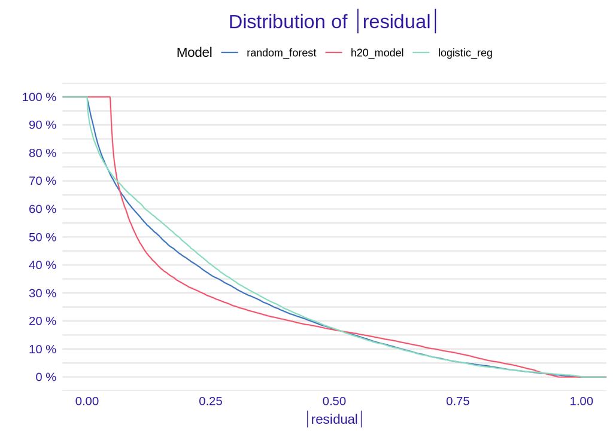

```r
plot(mp_h2o,mp_log_reg,mp_rf)
```

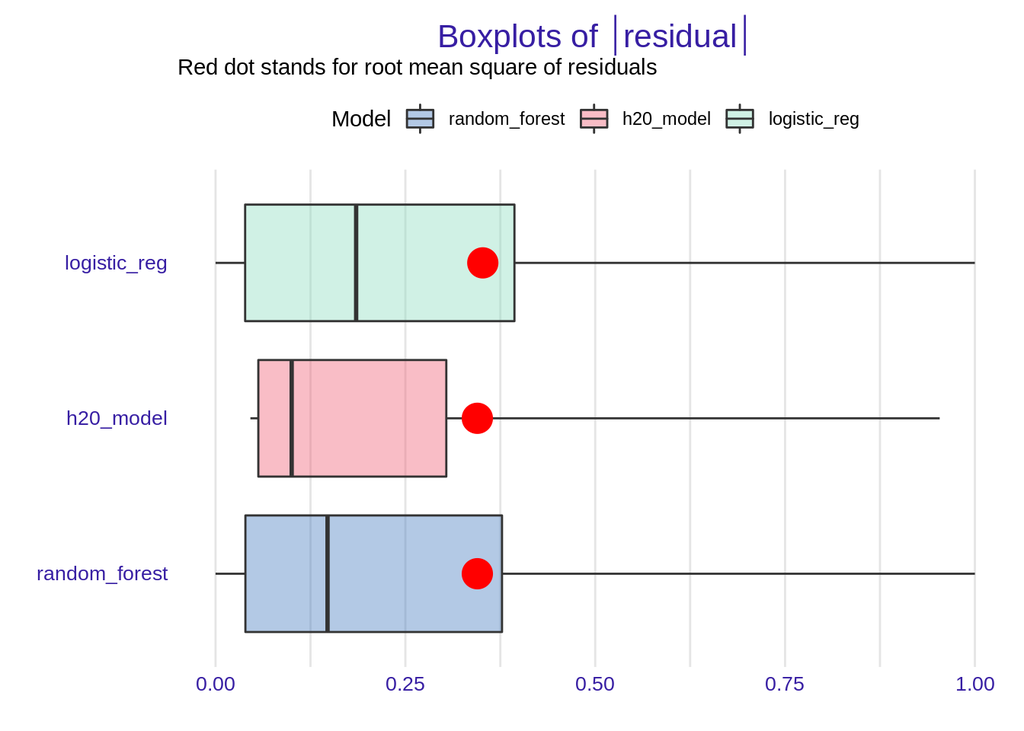

```r
plot(mp_h2o,mp_log_reg,mp_rf, geom = "boxplot")
```

## Feature Importance

```r
fi_h20 <- feature_importance(explainer_h20)
fi_log_reg <- feature_importance(explainer_log_reg)
fi_rf <- feature_importance(explainer_rf)

describe(fi_h20)
```

```
## The number of important variables for h20_model's prediction is 1 out of 23.
##  Variables B1_2 have the highest importantance.
```

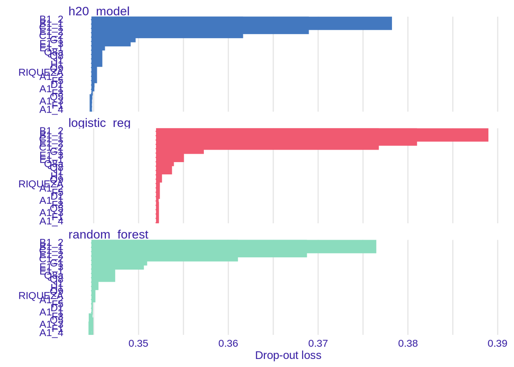

```r
plot(fi_h20,fi_log_reg,fi_rf)
```

## Variable explanation

### Accumulated Local Effects Profiles aka ALEPlots

Nota atribuída com respeito ao comprometimento da operadora em cumprir o que foi prometido e divulgado em sua publicidade.

```r
adp_h2o <- accumulated_dependency(explainer_h20,variables = "B1_2")
```

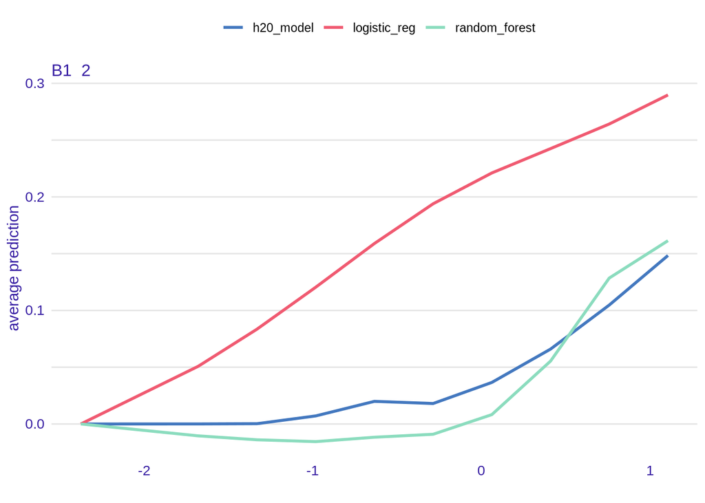

```r
adp_log_reg <- accumulated_dependency(explainer_log_reg,variables = "B1_2")
adp_rf <- accumulated_dependency(explainer_rf,variables = "B1_2")

plot(adp_h2o,adp_log_reg,adp_rf)
```

### Factor explanation

G1: Existência de outra operadora que ofereça o mesmo serviço da atual, no local onde o entrevistado mora:

1. Sim
2. Não
3. Não sabe

```r
expl_h2o <- variable_response(explainer_h20,variable = "G1", type = "factor")
```

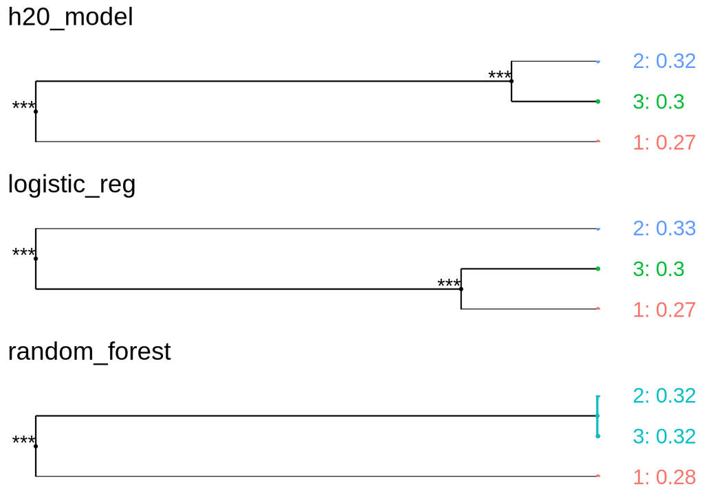

```r
expl_log_reg <- variable_response(explainer_log_reg,variable = "G1", type = "factor")
expl_rf<- variable_response(explainer_rf,variable = "G1", type = "factor")

plot(expl_h2o,expl_log_reg,expl_rf)
```

## Single prediction explanation

```r
bd_h2o <- break_down(explainer_h20, x_dalex[1,])
```

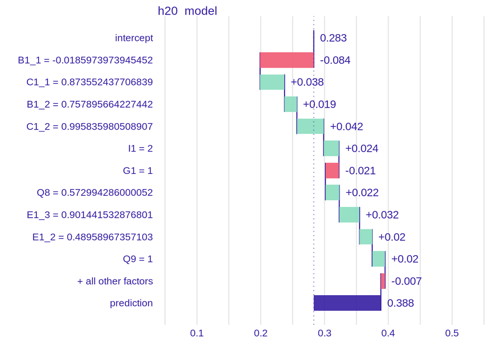

```r
bd_log_reg <- break_down(explainer_log_reg, x_dalex[1,])
bd_rf <- break_down(explainer_rf, x_dalex[1,])

plot(bd_h2o)
```

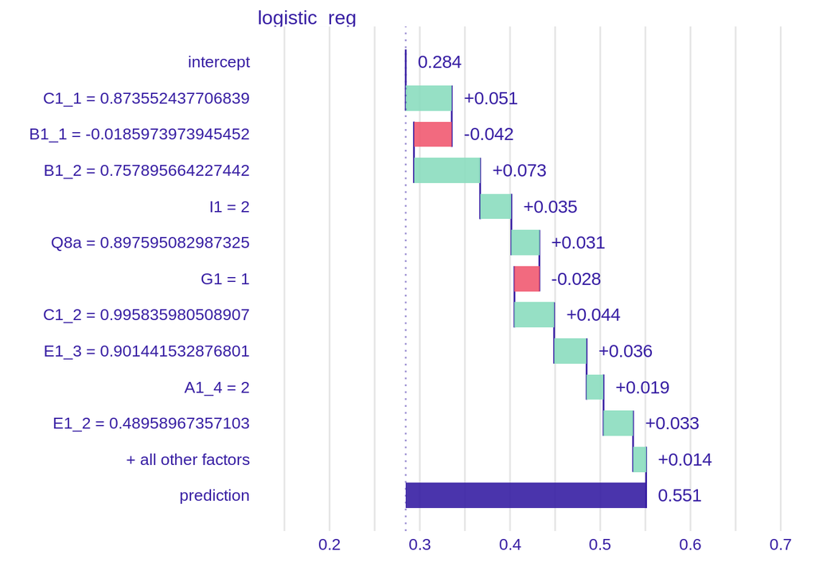

```r
plot(bd_log_reg)
```

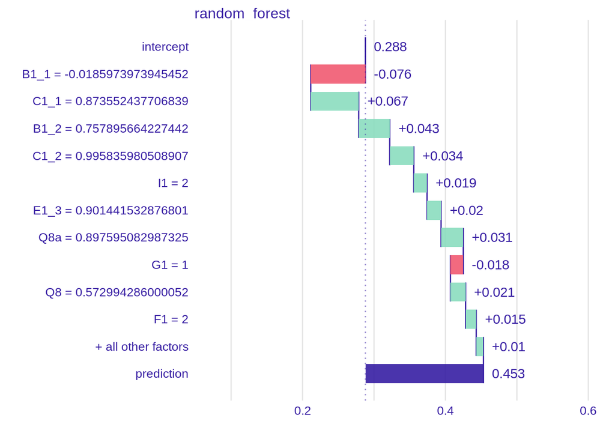

```r
plot(bd_rf)
```